# Injection Induced Seismicity Analysis

#### Bikash Pal & Girish Joshi

Beginning in 2009, the frequency of earthquakes in the U.S. State of Oklahoma rapidly increased from an average of fewer than two 3.0+ magnitude earthquakes per year since 1978 to hundreds per year in 2014, 2015, and 2016. Thousands of earthquakes have occurred in Oklahoma and surrounding areas in southern Kansas and North Texas since 2009. Scientific studies attribute the rise in earthquakes to the disposal of wastewater produced during oil extraction that has been injected deeply into the ground. (Wikipedia)

Injection wells are utilized to dispose of fluid created as a byproduct of oil and gas production activities. Likewise, hydraulic fracturing, ie "fracking", produces large byproducts of water. This byproduct is then injected deep back into the earth via disposal/injection wells.

##### Project Inspiration

1. Is there a correlation between earthquakes and injection well activity?
2. Can the data be used as a predictor of general proximity and/or time of future earthquakes ?

##### Acknowledgements

Data was gathered from Oklahoma Corporation Commission and The United States Geological Survey.

## Importing libraries

```python
import numpy as np
import pandas as pd
import matplotlib.pyplot as plt
import matplotlib.patches as mpatches
from mpl_toolkits.basemap import Basemap

%matplotlib inline

#pylab.rcParams['figure.figsize'] =
plt.rcParams["figure.figsize"] = (10.0, 8.0)

import warnings
warnings.filterwarnings('ignore')
```

## Importing & Cleaning Data

#### Injection Wells Dataset

```python
# Importing data

path = "InjectionWells.csv"
msft_inj_water = pd.read_csv(path)
msft_inj_water.head()
```

|  | API# | Operator | Operator ID | WellType | WellName | WellNumber | OrderNumbers | Approval Date | County | Sec | ... | Rng | QQQQ | LAT | LONG | PSI | BBLS | ZONE | Unnamed: 18 | Unnamed: 19 | Unnamed: 20 |
| --- | --- | --- | --- | --- | --- | --- | --- | --- | --- | --- | --- | --- | --- | --- | --- | --- | --- | --- | --- | --- | --- |
| 0 | 3.500300e+09 | PHOENIX PETROCORP INC | 19499.0 | 2R | SE EUREKA UNIT-TUCKER #1 | 21 | 133856.0 | 9/6/1977 | ALFALFA | 13 | ... | 10W | C-SE SE | 36.900324 | -98.21826 | 2,500 | 300 | CHEROKEE | NaN | NaN | NaN |
| 1 | 3.500300e+09 | CHAMPLIN EXPLORATION INC | 4030.0 | 2R | CHRISTENSEN | 1 | 470258.0 | 11/27/2002 | ALFALFA | 21 | ... | 09W | C-NW NW | 36.896636 | -98.17772 | 2,400 | 1,000 | RED FORK | NaN | NaN | NaN |
| 2 | 3.500321e+09 | LINN OPERATING INC | 22182.0 | 2R | NE CHEROKEE UNIT | 85 | 329426.0 | 8/19/1988 | ALFALFA | 24 | ... | 11W | SE NE | 36.806113 | -98.32584 | 1,050 | 1,000 | RED FORK | NaN | NaN | NaN |
| 3 | 3.500321e+09 | SANDRIDGE EXPLORATION & PRODUCTION LLC | 22281.0 | 2R | VELMA | 2-19 | 281652.0 | 7/11/1985 | ALFALFA | 19 | ... | 10W | SW NE NE SW | 36.888589 | -98.31853 | 3,152 | 1,000 | RED FORK | NaN | NaN | NaN |
| 4 | 3.500321e+09 | CHAMPLIN EXPLORATION INC | 4030.0 | 2R | GRAY | 1A | 470257.0 | 11/27/2002 | ALFALFA | 20 | ... | 09W | SE SW NW | 36.892128 | -98.19462 | 1,000 | 2,400 | RED FORK | NaN | NaN | NaN |

5 rows × 21 columns

```python
# Removing unused and corrupt data

msft_inj_water.drop(['Operator','Operator ID',
                     'WellType','WellName','WellNumber',
                     'OrderNumbers','County','Sec','Twp',
                     'Rng','QQQQ','ZONE','Unnamed: 18',
                     'Unnamed: 19','Unnamed: 20'], axis=1, inplace=True)
msft_inj_water.dropna(how='any',inplace=True)
msft_inj_water.head()
```

|  | API# | Approval Date | LAT | LONG | PSI | BBLS |
| --- | --- | --- | --- | --- | --- | --- |
| 0 | 3.500300e+09 | 9/6/1977 | 36.900324 | -98.21826 | 2,500 | 300 |
| 1 | 3.500300e+09 | 11/27/2002 | 36.896636 | -98.17772 | 2,400 | 1,000 |
| 2 | 3.500321e+09 | 8/19/1988 | 36.806113 | -98.32584 | 1,050 | 1,000 |
| 3 | 3.500321e+09 | 7/11/1985 | 36.888589 | -98.31853 | 3,152 | 1,000 |
| 4 | 3.500321e+09 | 11/27/2002 | 36.892128 | -98.19462 | 1,000 | 2,400 |

```python
# Preprocessing data

msft_inj_water['Approval Date'] = pd.to_datetime(msft_inj_water['Approval Date'])
msft_inj_water.sort_values('Approval Date',inplace=True)
msft_inj_water.reset_index(drop=True,inplace=True)
msft_inj_water['Approval Date'] = msft_inj_water['Approval Date'].dt.year
msft_inj_water['PSI'] = msft_inj_water['PSI'].str.replace(',','').convert_objects(convert_numeric=True)
msft_inj_water['BBLS'] = msft_inj_water['BBLS'].str.replace(',','').convert_objects(convert_numeric=True)
msft_inj_water.head()
```

|  | API# | Approval Date | LAT | LONG | PSI | BBLS |
| --- | --- | --- | --- | --- | --- | --- |
| 0 | 3.501923e+09 | 1936 | 34.199067 | -97.399092 | 1100.0 | 3500.0 |
| 1 | 3.508104e+09 | 1946 | 35.511472 | -96.767417 | 0.0 | 100.0 |
| 2 | 3.510500e+09 | 1947 | 36.718930 | -95.546017 | 0.0 | 4600.0 |
| 3 | 3.513704e+09 | 1947 | 34.453511 | -97.759898 | 350.0 | 1790.0 |
| 4 | 3.512504e+09 | 1948 | 35.343148 | -97.114245 | 400.0 | 5000.0 |

#### Classifying Injector Wells

```
[]
```

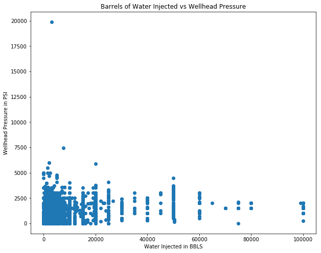

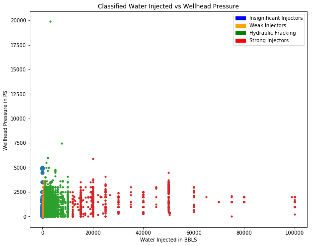

```python
# Injection Wells Statistics of Water Injected

water_injected = msft_inj_water.groupby('Approval Date').BBLS.agg(['count','mean','sum',]).reset_index()
water_injected['cum_water'] = water_injected['sum'].cumsum()

# Well Head Pressure Statistics

wellhead_pressure = msft_inj_water.groupby('Approval Date').PSI.agg(['count','mean',]).reset_index()

# Exploring Pressure vs BBLS data

plt.figure(1)
plt.scatter(msft_inj_water['BBLS'], msft_inj_water['PSI'])
plt.title('Barrels of Water Injected vs Wellhead Pressure')
plt.xlabel('Water Injected in BBLS')
plt.ylabel('Wellhead Pressure in PSI')

# Classifying Injection Wells using K-Means

#from sklearn.cluster import KMeans
#km = KMeans(n_clusters=4, max_iter=100)
#msftkm = msft_inj_water[['BBLS', 'PSI']]
#msftkm.dropna(how='any',inplace=True)
#km.fit(msftkm)
#km.cluster_centers_
#msft_inj_water['catagory'] = km.labels_

# Classifying Injection Wells in 4 classes

msft_inj_water['catagory'] = ''
msft_inj_water.loc[(msft_inj_water['BBLS']<=100),'catagory'] = 'insignificant'
msft_inj_water.loc[((msft_inj_water['BBLS']>100) & (msft_inj_water['BBLS']<=800)),'catagory'] = 'weak injection'
msft_inj_water.loc[(msft_inj_water['BBLS']>800) & (msft_inj_water['BBLS']<=10000),'catagory'] = 'fracking'
msft_inj_water.loc[(msft_inj_water['BBLS']>10000),'catagory'] = 'strong injection'


plt.figure(2)

plt.scatter(msft_inj_water.loc[(msft_inj_water['catagory'] == 'insignificant'),'BBLS'],
            msft_inj_water.loc[(msft_inj_water['catagory'] == 'insignificant'),'PSI'], s=50)

plt.scatter(msft_inj_water.loc[(msft_inj_water['catagory'] == 'weak injection'),'BBLS'],
            msft_inj_water.loc[(msft_inj_water['catagory'] == 'weak injection'),'PSI'], s=10)

plt.scatter(msft_inj_water.loc[(msft_inj_water['catagory'] == 'fracking'),'BBLS'],
            msft_inj_water.loc[(msft_inj_water['catagory'] == 'fracking'),'PSI'], s=10)

plt.scatter(msft_inj_water.loc[(msft_inj_water['catagory'] == 'strong injection'),'BBLS'],
            msft_inj_water.loc[(msft_inj_water['catagory'] == 'strong injection'),'PSI'], s=10)


plt.legend(handles=[mpatches.Patch(color='blue', label='Insignificant Injectors'),
                    mpatches.Patch(color='orange', label='Weak Injectors'),
                    mpatches.Patch(color='green', label='Hydraulic Fracking'),
                    mpatches.Patch(color='red', label='Strong Injectors')])


plt.title('Classified Water Injected vs Wellhead Pressure')
plt.xlabel('Water Injected in BBLS')
plt.ylabel('Wellhead Pressure in PSI')
plt.plot()
```

#### Earthquake Dataset

```python
# Importing data

pathq = "okQuakes.csv"
msft_quake = pd.read_csv(pathq)
msft_quake.head()
```

|  | time | latitude | longitude | depth | mag | magType | nst | gap | dmin | rms | ... | updated | place | type | horizontalError | depthError | magError | magNst | status | locationSource | magSource |
| --- | --- | --- | --- | --- | --- | --- | --- | --- | --- | --- | --- | --- | --- | --- | --- | --- | --- | --- | --- | --- | --- |
| 0 | 1973-03-17T07:43:05.500Z | 36.087 | -106.168 | 6.0 | 4.5 | mb | NaN | NaN | NaN | NaN | ... | 2014-11-06T23:21:10.078Z | New Mexico | earthquake | NaN | NaN | NaN | NaN | reviewed | us | us |
| 1 | 1973-05-25T14:40:13.900Z | 33.917 | -90.775 | 6.0 | NaN | NaN | NaN | NaN | NaN | NaN | ... | 2014-11-06T23:21:12.859Z | Mississippi | earthquake | NaN | NaN | NaN | NaN | reviewed | s | us |
| 2 | 1973-09-19T13:28:20.500Z | 37.160 | -104.594 | 5.0 | NaN | NaN | NaN | NaN | NaN | NaN | ... | 2014-11-06T23:21:20.295Z | Colorado | earthquake | NaN | NaN | NaN | NaN | reviewed | us | us |
| 3 | 1973-09-23T03:58:54.900Z | 37.148 | -104.571 | 5.0 | 4.2 | mb | NaN | NaN | NaN | NaN | ... | 2014-11-06T23:21:20.346Z | Colorado | earthquake | NaN | NaN | NaN | NaN | reviewed | us | us |
| 4 | 1974-02-15T13:33:49.200Z | 36.500 | -100.693 | 24.0 | 4.5 | mb | NaN | NaN | NaN | NaN | ... | 2014-11-06T23:21:22.859Z | Oklahoma | earthquake | NaN | NaN | NaN | NaN | reviewed | us | us |

5 rows × 22 columns

```python
# Removing unused and corrupt data

msft_quake.drop(['magType','nst','gap','dmin','rms','net','id','updated','place','type','status','locationSource','magSource','horizontalError','depthError','magError','magNst'], axis=1, inplace=True)
msft_quake.dropna(how='any',inplace=True)
msft_quake.head()
```

|  | time | latitude | longitude | depth | mag |
| --- | --- | --- | --- | --- | --- |
| 0 | 1973-03-17T07:43:05.500Z | 36.087 | -106.168 | 6.0 | 4.5 |
| 3 | 1973-09-23T03:58:54.900Z | 37.148 | -104.571 | 5.0 | 4.2 |
| 4 | 1974-02-15T13:33:49.200Z | 36.500 | -100.693 | 24.0 | 4.5 |
| 5 | 1974-02-15T22:32:34.600Z | 33.950 | -93.090 | 1.0 | 3.6 |
| 6 | 1974-02-15T22:35:44.700Z | 34.050 | -93.130 | 1.0 | 3.6 |

```python
# Removing unused and corrupt data

msft_quake['time']=pd.to_datetime(msft_quake['time'])
msft_quake.sort_values('time',inplace=True)
msft_quake.reset_index(drop=True,inplace=True)
msft_quake['time']=msft_quake['time'].dt.year
msft_quake.head()
```

|  | time | latitude | longitude | depth | mag |
| --- | --- | --- | --- | --- | --- |
| 0 | 1973 | 36.087 | -106.168 | 6.0 | 4.5 |
| 1 | 1973 | 37.148 | -104.571 | 5.0 | 4.2 |
| 2 | 1974 | 36.500 | -100.693 | 24.0 | 4.5 |
| 3 | 1974 | 33.950 | -93.090 | 1.0 | 3.6 |
| 4 | 1974 | 34.050 | -93.130 | 1.0 | 3.6 |

```python
# Earthquake Injections

depth_focus=msft_quake.groupby('time').depth.agg(['count','mean','sum']).reset_index()
mag_focus=msft_quake.groupby('time').mag.agg(['count','mean','sum']).reset_index()
```

## Setting up Basemap for Geographical Plotting

#### All injectors in overlay with earthquakes

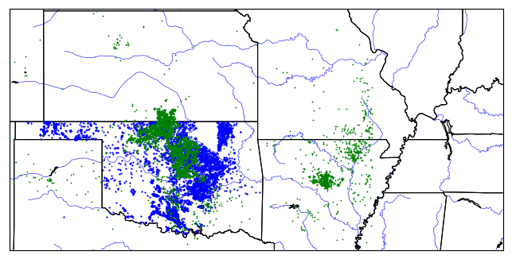

```python
# Initializing Basemap to Oklahoma

fig=plt.figure(figsize=(10, 8), dpi= 80, facecolor='w', edgecolor='k')

map = Basemap(projection='merc',
    #lat_0 = 57, lon_0 = -135,
    resolution = 'h', area_thresh = 0.1,
    llcrnrlon=-103.212667, llcrnrlat=33.365041,
    urcrnrlon=-86.137960, urcrnrlat=40.065066)

map.drawcoastlines()
map.drawcountries()
map.drawrivers(linewidth=0.5, linestyle='solid', color='blue', antialiased=1, ax=None, zorder=None)
map.drawstates(linewidth=1)
map.drawmapboundary()

# Geographical Data of Wells
lat_inj_water = msft_inj_water['LAT'].values
lon_inj_water = msft_inj_water['LONG'].values

# Geographical Data of Earthquakes
lat_quake = msft_quake['latitude'].values
lon_quake = msft_quake['longitude'].values

# Plotting Wells and Quakes
x,y = map(lon_inj_water, lat_inj_water)
xq, yq = map(lon_quake, lat_quake)
map.plot(x, y, 'bo', markersize=1)
map.plot(xq, yq, 'gx', markersize=1)
```

#### Insignigicant injectors in overlay with earthquakes

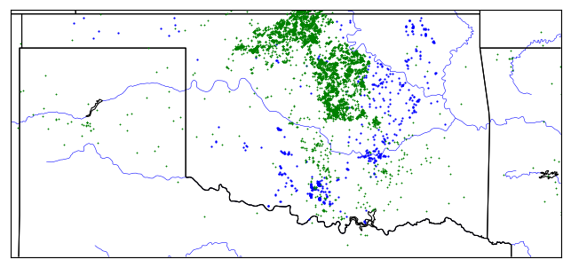

```python
fig = plt.figure(figsize=(10, 8), dpi= 80, facecolor='w', edgecolor='k')

map = Basemap(projection='merc',
    #lat_0 = 57, lon_0 = -135,
    resolution = 'h', area_thresh = 0.1,
    llcrnrlon=-103.212667, llcrnrlat=33.365041,
    urcrnrlon=-93.137960, urcrnrlat=37.065066)

map.drawcoastlines()
map.drawcountries()
map.drawrivers(linewidth=0.5, linestyle='solid', color='blue', antialiased=1, ax=None, zorder=None)
map.drawstates(linewidth=1)
map.drawmapboundary()

x1 = msft_inj_water.loc[(msft_inj_water['catagory'] == 'insignificant'), 'LONG'].values
y1 = msft_inj_water.loc[msft_inj_water['catagory'] == 'insignificant', 'LAT'].values

x2 = msft_inj_water.loc[msft_inj_water['catagory'] == 'weak injection', 'LONG'].values
y2 = msft_inj_water.loc[msft_inj_water['catagory'] == 'weak injection', 'LAT'].values

x3 = msft_inj_water.loc[msft_inj_water['catagory'] == 'fracking', 'LONG'].values
y3 = msft_inj_water.loc[msft_inj_water['catagory'] == 'fracking', 'LAT'].values

x4 = msft_inj_water.loc[msft_inj_water['catagory'] == 'strong injection', 'LONG'].values
y4 = msft_inj_water.loc[msft_inj_water['catagory'] == 'strong injection', 'LAT'].values


x1, y1 = map(x1, y1)
x2, y2 = map(x2, y2)
x3, y3 = map(x3, y3)
x4, y4 = map(x4, y4)

map.plot(x1, y1, 'bo', markersize=1, label='insignificant')
map.plot(xq, yq, 'gx', markersize=1)
```

#### Weak injectors in overlay with earthquakes

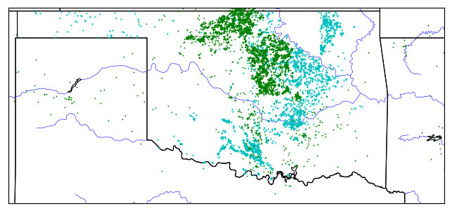

```python
fig = plt.figure(figsize=(10, 8), dpi= 80, facecolor='w', edgecolor='k')

map = Basemap(projection='merc',
    #lat_0 = 57, lon_0 = -135,
    resolution = 'h', area_thresh = 0.1,
    llcrnrlon=-103.212667, llcrnrlat=33.365041,
    urcrnrlon=-93.137960, urcrnrlat=37.065066)

map.drawcoastlines()
map.drawcountries()
map.drawrivers(linewidth=0.5, linestyle='solid', color='blue', antialiased=1, ax=None, zorder=None)
map.drawstates(linewidth=1)
map.drawmapboundary()

map.plot(x2, y2, 'co', markersize=1)
map.plot(xq, yq, 'gx', markersize=1)
```

#### Hydraulic fracturing in overlay with earthquakes

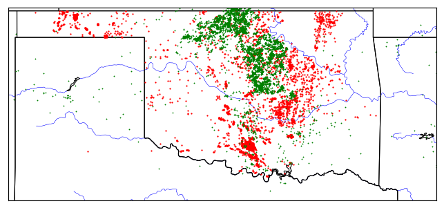

```python
fig = plt.figure(figsize=(10, 8), dpi= 80, facecolor='w', edgecolor='k')

map = Basemap(projection='merc',
    #lat_0 = 57, lon_0 = -135,
    resolution = 'h', area_thresh = 0.1,
    llcrnrlon=-103.212667, llcrnrlat=33.365041,
    urcrnrlon=-93.137960, urcrnrlat=37.065066)

map.drawcoastlines()
map.drawcountries()
map.drawrivers(linewidth=0.5, linestyle='solid', color='blue', antialiased=1, ax=None, zorder=None)
map.drawstates(linewidth=1)
map.drawmapboundary()

map.plot(x3, y3, 'ro', markersize=1)
map.plot(xq, yq, 'gx', markersize=1)
```

#### Strong injectors in overlay with earthquakes

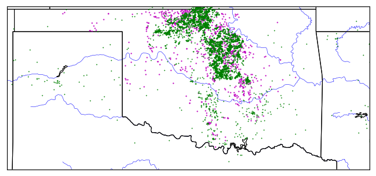

```python
fig = plt.figure(figsize=(10, 8), dpi= 80, facecolor='w', edgecolor='k')

map = Basemap(projection='merc',
    #lat_0 = 57, lon_0 = -135,
    resolution = 'h', area_thresh = 0.1,
    llcrnrlon=-103.212667, llcrnrlat=33.365041,
    urcrnrlon=-93.137960, urcrnrlat=37.065066)

map.drawcoastlines()
map.drawcountries()
map.drawrivers(linewidth=0.5, linestyle='solid', color='blue', antialiased=1, ax=None, zorder=None)
map.drawstates(linewidth=1)
map.drawmapboundary()

map.plot(x4, y4, 'mo', markersize=1)
map.plot(xq, yq, 'gx', markersize=1)
```

#### Curve fitting on Well Count vs Time and Earthqauke vs Time

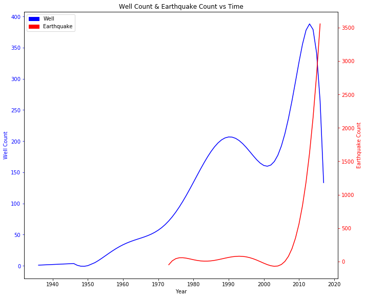

```python
z1 = np.polyfit(water_injected['Approval Date'], water_injected['count'], 50)
f1 = np.poly1d(z1)
water_new = f1(water_injected['Approval Date'])

z2 = np.polyfit(depth_focus['time'], depth_focus['count'], 15)
f2 = np.poly1d(z2)
quake_new = f2(depth_focus['time'])

fig, ax1 = plt.subplots()
ax1.plot(water_injected['Approval Date'], water_new, 'b-')
ax1.set_xlabel('Year')
ax1.set_ylabel('Well Count', color='b')
ax1.tick_params('y', colors='b')

ax2 = ax1.twinx()
ax2.plot(depth_focus['time'], quake_new, 'r-')
ax2.set_ylabel('Earthquake Count', color='r')
ax2.tick_params('y', colors='r')
fig.tight_layout()

plt.legend(handles=[mpatches.Patch(color='blue', label='Well'), mpatches.Patch(color='red', label='Earthquake')])
plt.title('Well Count & Earthquake Count vs Time')
plt.show()
```

#### Plotting Annual Water Injeccted & Earthquake Count vs Time

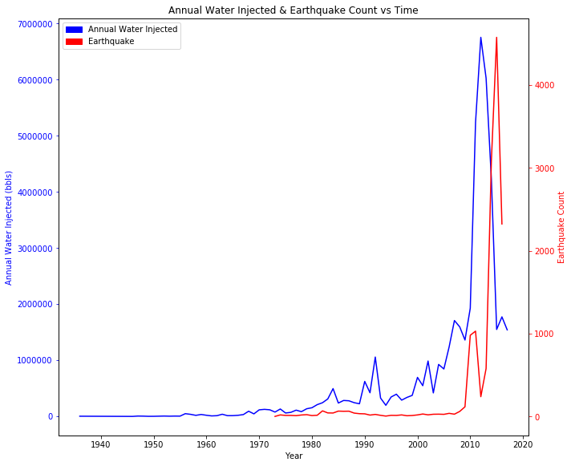

```python
water_sum_new = water_injected['sum']
quake_new = depth_focus['count']

fig, ax1 = plt.subplots()
ax1.plot(water_injected['Approval Date'], water_sum_new, 'b-')
ax1.set_xlabel('Year')
ax1.set_ylabel('Annual Water Injected (bbls)', color='b')
ax1.tick_params('y', colors='b')

ax2 = ax1.twinx()
ax2.plot(depth_focus['time'], quake_new, 'r-')
ax2.set_ylabel('Earthquake Count', color='r')
ax2.tick_params('y', colors='r')
fig.tight_layout()

plt.legend(handles=[mpatches.Patch(color='blue', label='Annual Water Injected'), mpatches.Patch(color='red', label='Earthquake')])
plt.title('Annual Water Injected & Earthquake Count vs Time')
plt.show()
```

#### Curve fitting mean wellhead pressures vs time

Over time the mean wellhead pressure is increasing. Mean wellhead pressure is proportional to the depth of the well, bottom hole pressure, and production rate for a given fluid gradient.

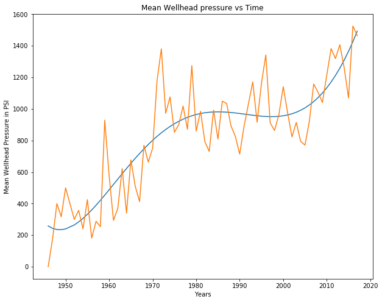

```python
z3 = np.polyfit(wellhead_pressure['Approval Date'][1:], wellhead_pressure['mean'][1:], 5)
f3 = np.poly1d(z3)
well_new = f3(wellhead_pressure['Approval Date'][1:])

plt.plot(wellhead_pressure['Approval Date'][1:], well_new)
plt.plot(wellhead_pressure['Approval Date'][1:], wellhead_pressure['mean'][1:])
plt.xlabel('Years')
plt.ylabel('Mean Wellhead Pressure in PSI')
plt.title('Mean Wellhead pressure vs Time')
```

## Analysis Process

1. Data Imported & Cleaned.
2. Injector wells were classified into four categories: Insignificant, Weak, Hydraulic Fracturing, Strong.
3. Setup Basemap for Geographical Plotting.
4. Studied overlay of earthquake data with the four categories of injectors.
5. Plotted Well Count vs Year and Earthquak Count vs Year.
6. Plotted Water Injected vs Years and Earthquak Count vs Year.
7. Plotted Mean Wellhead Pressure vs Years.

## Concluding Remarks

1. Hydraulic fracturing Wells & Strong Injectors seems to be the major cause factor for the earthquakes.
2. The shale boom in US is well depicted in the analysis between 2005 and 2014 with injection activities increasing manifold.
3. Increasing injection activities are well correlated with the increasing earthquakes with a short time lag.
4. Over time the mean wellhead pressure is increasing. Mean wellhead pressure is proportional to the depth of the well, bottom hole pressure, and production rate for a given fluid gradient.
5. It is observed that majority of injection activites and Earthquakes Canadadian River and Arkansas River. These rivers would have acted as a good source of water for injection activites.

## Future Work

1. After establishing correlationship, the next task would be to predict the proximity and time of future earthquakes.
2. Generating a thematic map of the state by gridding the space and filling it with average/cummulative water injected to understand the underground water reserves.